# mclust 5: Clustering, Classification and Density Estimation Using Gaussian Finite Mixture Models

(b)

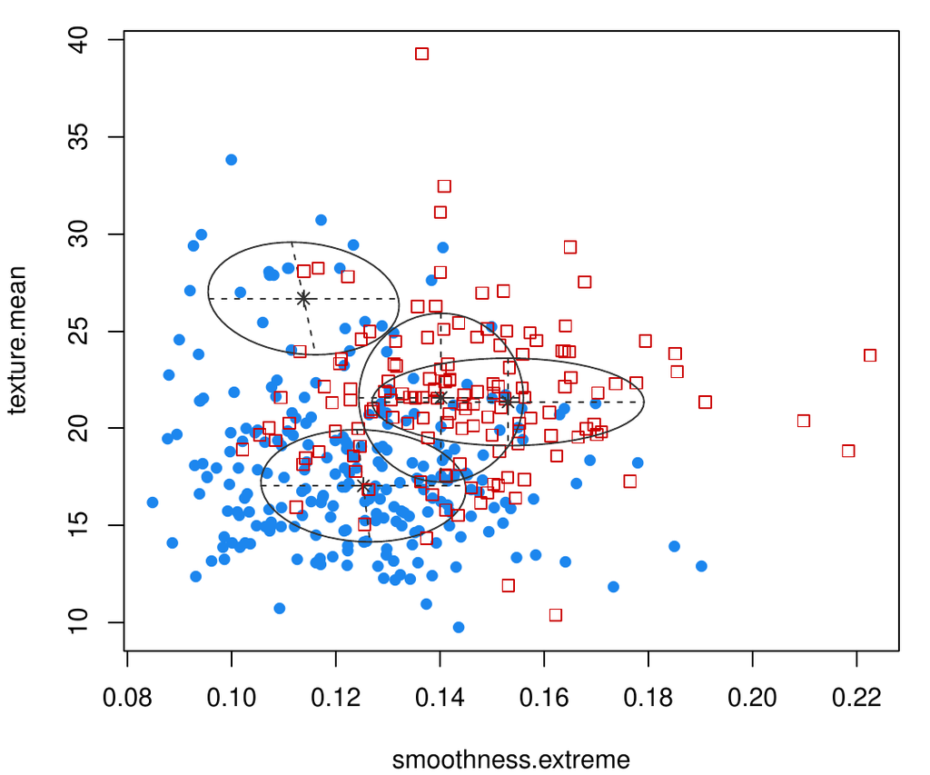

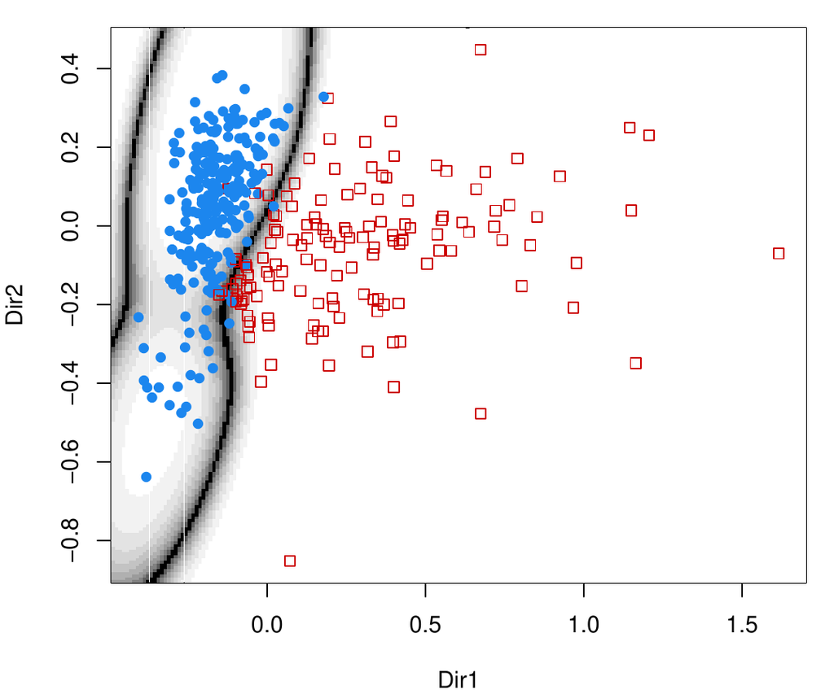

(c)

(d)

Figure 15: Pairwise scatterplots between variables for the Wisconsin breast cancer data (panels a–c). Points are marked by cancer diagnosis (benign = $•$, malignant = $▫$), whereas ellipses correspond to covariances of mixture components estimated with `MclustDA`. Plot of data projected along the first two estimated directions obtained with `MclustDR`, and uncertainty classification boundaries (d).

Finally, note that the MDA model is equivalent to MclustDA with $\mathbf{\Sigma}_{k} = \lambda\mathbf{D}\mathbf{A}\mathbf{D}{}^{\!\top}$ (model EEE) and fixed $G_k \ge 1$ for each $k=1,\ldots,K$. For instance, a MDA with two mixture components for each class can be fitted as:

```r
> mod3 <- MclustDA(X.train, Class.train, G = 2, modelNames = "EEE")
> summary(mod3, newdata = X.test, newclass = Class.test)
------------------------------------------------
Gaussian finite mixture model for classification
------------------------------------------------

MclustDA model summary:

 log.likelihood   n df       BIC
      -2968.077 379 26 -6090.531

Classes   n Model G
      B 238   EEE 2
      M 141   EEE 2

Training classification summary:

     Predicted
Class   B   M
    B 235   3
    M  12 129

Training error = 0.03957784

Test classification summary:

     Predicted
Class   B   M
    B 113   6
    M   2  69

Test error = 0.04210526
```

# Summary

*mclust* is one of the most popular R packages for Gaussian mixture modelling. Since its early developments (Banfield and Raftery 1993; Fraley and Raftery 1998, 1999), *mclust* has seen major updates through the years, which expanded its capabilities and features, increasing its popularity and widening its area of utilisation.

Here we have presented the most salient new features introduced in version $\ge 5$, namely new covariance parameterisations, subspace data visualisation, different model selection criteria, bootstrap-based inference and EM algorithm initialisation. We showed their application on a collection of different datasets, pointing out their utility in different contexts.

# Acknowledgments

Michael Fop and T. Brendan Murphy were supported by the Science Foundation Ireland funded Insight Research Centre (SFI/12/RC/2289). Adrian E. Raftery and Luca Scrucca were supported by NIH grants R01 HD054511, R01 HD070936 and U54 HL127624.

Ahlquist, John S, and Christian Breunig. 2012. “Model-Based Clustering and Typologies in the Social Sciences.” *Political Analysis* 20 (1): 92–112.

Aitkin, Murray, and Donald B. Rubin. 1985. “Estimation and Hypothesis Testing in Finite Mixture Models.” *Journal of the Royal Statistical Society: Series B (Statistical Methodology)* 47 (1): 67–75.

Banfield, J., and Adrian E. Raftery. 1993. “Model-Based Gaussian and Non-Gaussian Clustering.” *Biometrics* 49: 803–21.

Basford, K E, D R Greenway, G J McLachlan, and D Peel. 1997. “Standard Errors of Fitted Component Means of Normal Mixtures.” *Computational Statistics* 12 (1): 1–18.

Benaglia, Tatiana, Didier Chauveau, David R. Hunter, and Derek Young. 2009. “mixtools: An R Package for Analyzing Finite Mixture Models.” *Journal of Statistical Software* 32 (6): 1–29. http://www.jstatsoft.org/v32/i06/.

Bensmail, H., and G. Celeux. 1996. “Regularized Gaussian Discriminant Analysis Through Eigenvalue Decomposition.” *Journal of the American Statistical Association* 91: 1743–48.

Biecek, Przemysław, Ewa Szczurek, Martin Vingron, and Jerzy Tiuryn. 2012. “The R Package bgmm: Mixture Modeling with Uncertain Knowledge.” *Journal of Statistical Software* 47 (3): 1–32. http://www.jstatsoft.org/v47/i03/.

Biernacki, C., G. Celeux, and G. Govaert. 2000. “Assessing a Mixture Model for Clustering with the Integrated Completed Likelihood.” *IEEE Transactions on Pattern Analysis and Machine Intelligence* 22 (7): 719–25.

Brin, Sergey, and Lawrence Page. 1998. “The Anatomy of a Large-Scale Hypertextual Web Search Engine.” In *Proceedings of the Seventh International Conference on World Wide Web*, 107–17.

Browne, Ryan P., Aisha ElSherbiny, and Paul D. McNicholas. 2015. *Mixture: Mixture Models for Clustering and Classification*. https://CRAN.R-project.org/package=mixture.

Browne, Ryan P, and Paul D McNicholas. 2014. “Estimating Common Principal Components in High Dimensions.” *Advances in Data Analysis and Classification* 8 (2): 217–26.

Campbell, Jonathan G, Chris Fraley, D Stanford, Fionn Murtagh, and Adrian E. Raftery. 1999. “Model-Based Methods for Textile Fault Detection.” *International Journal of Imaging Systems and Technology* 10 (4): 339–46.

Celeux, G., and G. Govaert. 1995. “Gaussian Parsimonious Clustering Models.” *Pattern Recognition* 28: 781–93.

Chen, Wei-Chen, and Ranjan Maitra. 2015. *EMCluster: EM Algorithm for Model-Based Clustering of Finite Mixture Gaussian Distribution*. https://CRAN.R-project.org/package=EMCluster.

Csardi, Gabor. 2015. *Cranlogs: Download Logs from the RStudio CRAN Mirror*. https://github.com/metacran/cranlogs.

Csardi, Gabor, and Tamas Nepusz. 2006. “The Igraph Software Package for Complex Network Research.” *InterJournal* Complex Systems: 1695. http://igraph.org.

Dempster, A P, N M Laird, and D B Rubin. 1977. “Maximum Likelihood from Incomplete Data via the EM Algorithm.” *Journal of the Royal Statistical Society: Series B (Statistical Methodology)* 39 (1): 1–38.

Efron, Bradley. 1979. “Bootstrap Methods: Another Look at the Jackknife.” *The Annals of Statistics* 7: 1–26.

Ellefsen, K. J., D. B. Smith, and J. D. Horton. 2014. “A Modified Procedure for Mixture-Model Clustering of Regional Geochemical Data.” *Applied Geochemistry* 51: 315–26.

Flynt, A., and M. I. G. Daepp. 2015. “Diet-Related Chronic Disease in the Northeastern United States: A Model-Based Clustering Approach.” *International Journal of Health Geographics* 14 (1): 1–14.

Fraley, Chris. 1998. “Algorithms for Model-Based Gaussian Hierarchical Clustering.” *SIAM Journal on Scientific Computing* 20 (1): 270–81.

Fraley, Chris, and Adrian E Raftery. 2007a. “Bayesian Regularization for Normal Mixture Estimation and Model-Based Clustering.” *Journal of Classification* 24 (2): 155–81.

Fraley, Chris, and Adrian E. Raftery. 1998. “How Many Clusters? Which Clustering Method? Answers via Model-Based Cluster Analysis.” *The Computer Journal* 41: 578–88.

———. 1999. “MCLUST: Software for Model-Based Cluster Analysis.” *Journal of Classification* 16 (2): 297–306.

———. 2002. “Model-Based Clustering, Discriminant Analysis, and Density Estimation.” *Journal of the American Statistical Association* 97 (458): 611–31.

———. 2003. “Enhanced Model-Based Clustering, Density Estimation, and Discriminant Analysis Software: MCLUST.” *Journal of Classification* 20 (2): 263–86.

———. 2006a. “Model-Based Microarray Image Analysis.” *R News* 6 (5): 60–63. http://CRAN.R-project.org/doc/Rnews/Rnews_2006-5.pdf.

———. 2006b. “Some Applications of Model-Based Clustering in Chemistry.” *R News* 6 (3): 17–23. http://CRAN.R-project.org/doc/Rnews/Rnews_2006-3.pdf.

———. 2007b. “Model-Based Methods of Classification: Using the Mclust Software in Chemometrics.” *Journal of Statistical Software* 18 (6): 1–13. http://www.jstatsoft.org/v018/i06/.

Fraley, Chris, Adrian E. Raftery, Thomas Brendan Murphy, and Luca Scrucca. 2012. “MCLUST Version 4 for R: Normal Mixture Modeling for Model-Based Clustering, Classification, and Density Estimation.” Technical Report 597. Department of Statistics, University of Washington.

Fraley, Chris, Adrian E. Raftery, and Luca Scrucca. 2016. *Mclust: Gaussian Mixture Modelling for Model-Based Clustering, Classification, and Density Estimation*. https://CRAN.R-project.org/package=mclust.

Grün, Bettina, and Friedrich Leisch. 2007. “Fitting Finite Mixtures of Generalized Linear Regressions in R.” *Computational Statistics & Data Analysis* 51 (11): 5247–52.

———. 2008. “FlexMix Version 2: Finite Mixtures with Concomitant Variables and Varying and Constant Parameters.” *Journal of Statistical Software* 28 (4): 1–35. http://www.jstatsoft.org/v28/i04/.

Habbema, J D F, J. Hermans, and K van den Broek. 1974. “A Stepwise Discriminant Analysis Program Using Density Estimation.” In *Proceedings in Computational Statistics*, 101–10. Vienna: Physica-Verlag: COMPSTAT.

Hastie, T., and R. Tibshirani. 1996. “Discriminant Analysis by Gaussian Mixtures.” *Journal of the Royal Statistical Society: Series B (Statistical Methodology)* 58 (1): 155–76.

Hennig, Christian. 2004. “Asymmetric Linear Dimension Reduction for Classification.” *Journal of Computational and Graphical Statistics* 13 (4): 930–45.

———. 2015. *Fpc: Flexible Procedures for Clustering*. https://CRAN.R-project.org/package=fpc.

Hubert, L., and P. Arabie. 1985. “Comparing Partitions.” *Journal of Classification* 2: 193–218.

Hurley, Catherine. 2012. *Gclus: Clustering Graphics*. https://CRAN.R-project.org/package=gclus.

Izenman, A. J. 2008. *Modern Multivariate Statistical Techniques: Regression, Classification, and Manifold Learning*. New York: Springer-Verlag.

Izenman, Alan J, and Charles J Sommer. 1988. “Philatelic Mixtures and Multimodal Densities.” *Journal of the American Statistical Association* 83 (404): 941–53.

Jang, Jaewon, and David B Hitchcock. 2012. “Model-Based Cluster Analysis of Democracies.” *Journal of Data Science* 10 (2): 297–319.

Kazor, K., and A. S. Hering. 2015. “Assessing the Performance of Model-Based Clustering Methods in Multivariate Time Series with Application to Identifying Regional Wind Regimes.” *Journal of Agricultural, Biological and Environmental Statistics* 20: 192–217.

Keribin, C. 2000. “Consistent Estimation of the Order of Mixture Models.” *Sankhyā: The Indian Journal of Statistics, Series A (1961–2002)* 62 (1): 49–66.

Kim, K. H., S. T. Yun, S. S. Park, Y. Joo, and T. S. Kim. 2014. “Model-Based Clustering of Hydrochemical Data to Demarcate Natural Versus Human Impacts on Bedrock Groundwater Quality in Rural Areas, South Korea.” *Journal of Hydrology* 519: 626–36.

Konigsberg, Lyle W, Bridget F B Algee-Hewitt, and Dawnie W Steadman. 2009. “Estimation and Evidence in Forensic Anthropology: Sex and Race.” *American Journal of Physical Anthropology* 139: 77–90.

Konishi, Sadanori, and Genshiro Kitagawa. 1996. “Generalised Information Criteria in Model Selection.” *Biometrika* 83 (4): 875–90.

Kozak, Marcin, and Christine H Scaman. 2008. “Unsupervised Classification Methods in Food Sciences: Discussion and Outlook.” *Journal of the Science of Food and Agriculture* 88 (7): 1115–27.

Lebret, Rémi, Serge Iovleff, Florent Langrognet, Christophe Biernacki, Gilles Celeux, and Gérard Govaert. 2015. “Rmixmod: The R Package of the Model-Based Unsupervised, Supervised, and Semi-Supervised Classification Mixmod Library.” *Journal of Statistical Software* 67 (6): 1–29. http://www.jstatsoft.org/v067/i06/.

Leisch, Friedrich. 2004. “FlexMix: A General Framework for Finite Mixture Models and Latent Class Regression in R.” *Journal of Statistical Software* 11 (8): 1–18. http://www.jstatsoft.org/v11/i08/.

Li, Q., C. Fraley, R. E. Bumgarner, and A. E. Raftery. 2005. “Donuts, Scratches and Blanks: Robust Model-Based Segmentation of Microarray Images.” *Bioinformatics* 21: 2875–82.

Mangasarian, Olvi L, W Nick Street, and William H Wolberg. 1995. “Breast Cancer Diagnosis and Prognosis via Linear Programming.” *Operations Research* 43 (4): 570–77.

McLachlan, G. J., and D. Peel. 2000. *Finite Mixture Models*. New York: Wiley.

McLachlan, Geoffrey J. 1987. “On Bootstrapping the Likelihood Ratio Test Statistic for the Number of Components in a Normal Mixture.” *Applied Statistics* 36: 318–24.

McLachlan, Geoffrey J, and Suren Rathnayake. 2014. “On the Number of Components in a Gaussian Mixture Model.” *Wiley Interdisciplinary Reviews: Data Mining and Knowledge Discovery* 4 (5): 341–55.

Newton, Michael A., and Adrian E. Raftery. 1994. “Approximate Bayesian Inference with the Weighted Likelihood Bootstrap (with Discussion).” *Journal of the Royal Statistical Society: Series B (Statistical Methodology)* 56: 3–48.

O’Hagan, A., T. Brendan Murphy, and I. C. Gormley. 2015. “On Estimation of Parameter Uncertainty in Model-Based Clustering.” *ArXiv e-Prints*, October. http://arxiv.org/abs/1510.00551.

Roeder, Kathryn, and Larry Wasserman. 1997. “Practical Bayesian Density Estimation Using Mixtures of Normals.” *Journal of the American Statistical Association* 92 (439): 894–902.

Schwartz, G. 1978. “Estimating the Dimension of a Model.” *The Annals of Statistics* 6: 31–38.

Scrucca, L., and A. E. Raftery. 2015. “Improved Initialisation of Model-Based Clustering Using Gaussian Hierarchical Partitions.” *Advances in Data Analysis and Classification* 4 (9): 447–60.

Scrucca, Luca. 2010. “Dimension Reduction for Model-Based Clustering.” *Statistics and Computing* 20 (4): 471–84.

———. 2014. “Graphical Tools for Model-Based Mixture Discriminant Analysis.” *Advances in Data Analysis and Classification* 8 (2): 147–65.

Suveg, Cynthia, Marni L. Jacob, Monica Whitehead, Anna Jones, and Julie Newman Kingery. 2014. “A Model-Based Cluster Analysis of Social Experiences in Clinically Anxious Youth: Links to Emotional Functioning.” *Anxiety, Stress, & Coping* 27 (5): 494–508.

Templ, M., P. Filzmoser, and C. Reimann. 2008. “Cluster Analysis Applied to Regional Geochemical Data – Problems and Possibilities.” *Applied Geochemistry* 23: 2198–2213.

Todorov, Valentin, and Peter Filzmoser. 2009. “An Object-Oriented Framework for Robust Multivariate Analysis.” *Journal of Statistical Software* 32 (3): 1–47. http://www.jstatsoft.org/v32/i03/.

Verbist, B., L. Clement, J. Reumers, K. Thys, A. Vapirev, W. Talloen, Y. Wetzels, et al. 2015. “ViVaMBC: Estimating Viral Sequence Variation in Complex Populations from Illumina Deep-Sequencing Data Using Model-Based Clustering.” *BMC Bioinformatics* 16 (1): 1–11.

Wickham, Hadley, Dianne Cook, Heike Hofmann, and Andreas Buja. 2011. “tourr: An R Package for Exploring Multivariate Data with Projections.” *Journal of Statistical Software* 40 (2): 1–18. http://www.jstatsoft.org/v40/i02/.

Wu, CF Jeff. 1983. “On the Convergence Properties of the EM Algorithm.” *The Annals of Statistics* 11 (1): 95–103.

Yeung, K. Y., Chris Fraley, A. Murua, Adrian E. Raftery Raftery, and W. L. Ruzzo. 2001. “Model-Based Clustering and Data Transformations for Gene Expression Data.” *Bioinformatics* 17 (10): 977–87.

[^1]: See http://piccolboni.info/2012/05/essential-r-packages.html.
[^2]: The Hidalgo stamp data is available at the home page for the book by A. J. Izenman (2008) at http://astro.temple.edu/~alan/MMST/datasets.html, or through the package *MMST*. The latter has been archived on CRAN, so it must be installed using the following code:  
    `> install.packages("http://cran.r-project.org/src/contrib/Archive/MMST/MMST_0.6-1.1.tar.gz", repos = NULL, type = "source")`